# Module 188

#### Hemi-module gene counts:

139 probesets in hemi-module A.  
137 probesets in hemi-module B.  
Note: While the mapping of probesets to genes is usually one-to-one, some genes are targeted by multiple probesets, some probesets target multiple genes, and some probesets do not target any genes (i.e., the region of the genome they match is no longer considered genic).

#### Contrast SVE:

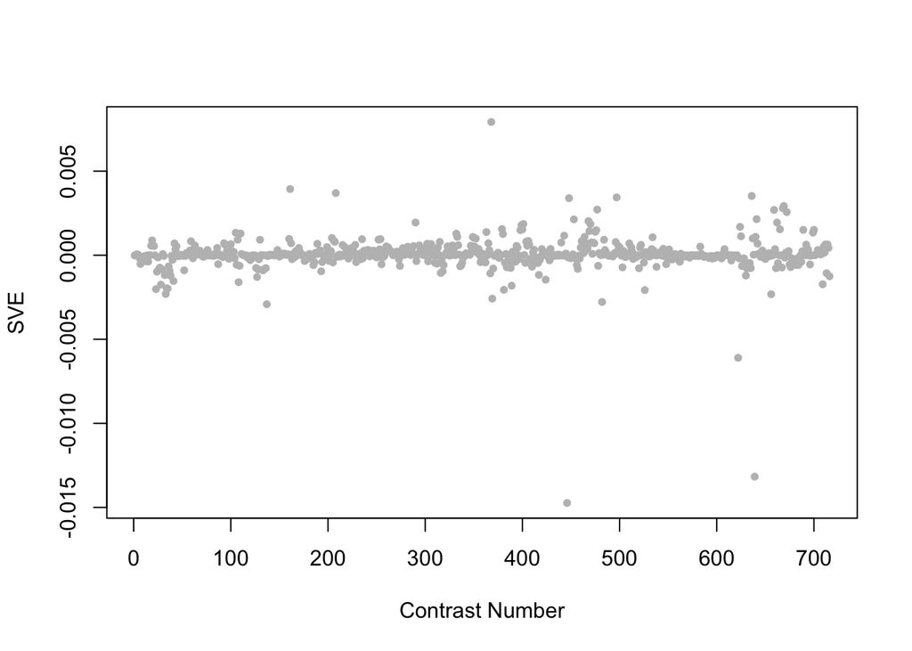

Positive SVE Contrasts:

|  | Contrast.Num | SVE | GEO.GSE | Cond.1 | Cond.2 | Mutation |
| --- | --- | --- | --- | --- | --- | --- |
| GSE35360A.s2t1.vs.s0t1 | 368 | 0.01 | GSE35360 | HF 11d_2.0_rep1 | HF 11d control_rep1 |  |
| GSE47778.s4t2.vs.s3t2 | 161 | 0.00 | GSE47778 | daf-2;daf-16; starvation; replicate 1 | daf-16; starvation; replicate 1 | daf-2;daf-16 vs. daf-16 |
| GSE42703.s2t2.vs.s2t1 | 208 | 0.00 | GSE42703 | WT incubated with H2O, biological rep1 | WT incubated with 1mM copper sulfate, biological rep1 |  |
| GSE18132.s2t2.vs.s0t2 | 636 | 0.00 | GSE18132 | Oga Fed L4, biological replicate 1 | WT Fed L4, biological rep1 | oga-1 |
| GSE23528C.s1t6.vs.s1t1 | 497 | 0.00 | GSE23528 | Adult at T46 in DD, time-series experiment 2 | Adult at T26 in DD, time-series experiment 2 |  |

Negative SVE Contrasts:

|  | Contrast.Num | SVE | GEO.GSE | Cond.1 | Cond.2 | Mutation |
| --- | --- | --- | --- | --- | --- | --- |
| GSE27401.s2t1.vs.s3t1 | 446 | -0.01 | GSE27401 | Heat Killed C. albicans #1 | C. albicans alive #1 |  |
| GSE18132.s1t1.vs.s0t1 | 639 | -0.01 | GSE18132 | Ogt starved L1, biological replicate 1 | WT Starved L1, biological rep1 | ogt-1 |
| GSE21162.s1t1.vs.s0t1 | 622 | -0.01 | GSE21162 | PVD and OLL neurons, biological rep1 | L3/L4 stage whole animal reference, rep1 |  |
| GSE51691.s3t1.vs.s1t1 | 137 | -0.00 | GSE51691 | day8 hermaphrodite utx-1 RNAi -males rep 1 | day8 hermaphrodite -males rep 1 | utx-1(RNAi) |
| GSE23528A.s2t2.vs.s2t1 | 482 | -0.00 | GSE23528 | Adult at T6 in WC, time-series experiment 1 | Adult at T2 in WC, time-series experiment 1 |  |

$~$

#### Contrast SVE, Up-Regulated Genes Only:

Calculating SVE for up-regulated and down-regulated genes separately may be more informative in many cases than projecting the up- and down- gene sets together. This is due to the fact that the weight distribution of many modules is highly skewed, indicating that only one of the hemi-modules may be biologically meaningful (i.e., a set of genes are strongly correlated by only a few genes (or none) are strongly anti-correlated to that set.)

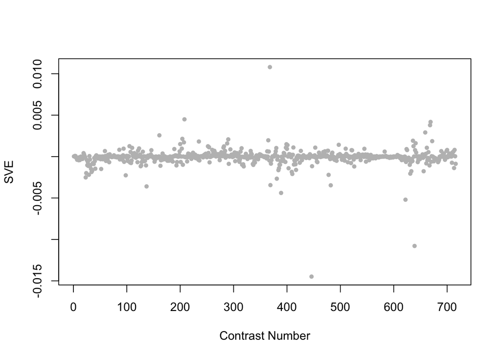

Positive SVE Contrasts:

|  | Contrast.Num | SVE | GEO.GSE | Cond.1 | Cond.2 | Mutation |
| --- | --- | --- | --- | --- | --- | --- |
| GSE35360A.s2t1.vs.s0t1 | 368 | 0.01 | GSE35360 | HF 11d_2.0_rep1 | HF 11d control_rep1 |  |
| GSE42703.s2t2.vs.s2t1 | 208 | 0.00 | GSE42703 | WT incubated with H2O, biological rep1 | WT incubated with 1mM copper sulfate, biological rep1 |  |
| GSE15016.s3t1.vs.s0t1 | 669 | 0.00 | GSE15016 | young adult_24hr DEHP exposure_rep1 | young adult_not exposured_rep1 |  |
| GSE15016.s4t1.vs.s0t1 | 668 | 0.00 | GSE15016 | young adult_24hr BPA exposure_rep1 | young adult_not exposured_rep1 |  |
| GSE15762.s1t1.vs.s0t1 | 659 | 0.00 | GSE15762 | hlh-30(tm1978)-1 | N2-1 | hlh-30 |

Negative SVE Contrasts:

|  | Contrast.Num | SVE | GEO.GSE | Cond.1 | Cond.2 | Mutation |
| --- | --- | --- | --- | --- | --- | --- |
| GSE27401.s2t1.vs.s3t1 | 446 | -0.01 | GSE27401 | Heat Killed C. albicans #1 | C. albicans alive #1 |  |
| GSE18132.s1t1.vs.s0t1 | 639 | -0.01 | GSE18132 | Ogt starved L1, biological replicate 1 | WT Starved L1, biological rep1 | ogt-1 |
| GSE21162.s1t1.vs.s0t1 | 622 | -0.01 | GSE21162 | PVD and OLL neurons, biological rep1 | L3/L4 stage whole animal reference, rep1 |  |
| GSE32942.s2t1.vs.s1t1 | 389 | -0.00 | GSE32942 | WS5041 (mir 58(n4640); alg 1(tm492); opIs205). Replicate 1 | WS4303 (alg 1(tm492); opIs205). Replicate 1 | mir-58 |
| GSE51691.s3t1.vs.s1t1 | 137 | -0.00 | GSE51691 | day8 hermaphrodite utx-1 RNAi -males rep 1 | day8 hermaphrodite -males rep 1 | utx-1(RNAi) |

$~$

#### Contrast SVE, Down-Regulated Genes Only:

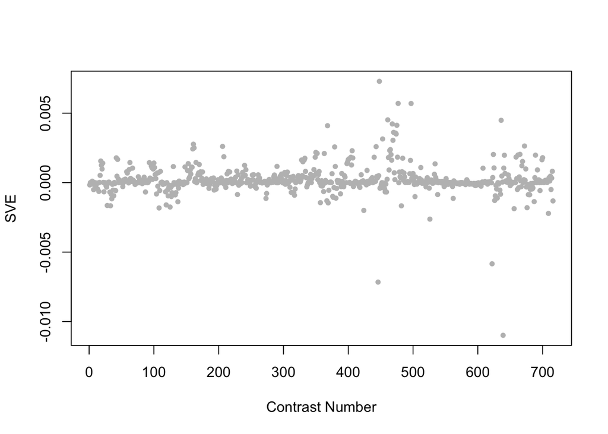

Positive SVE Contrasts:

|  | Contrast.Num | SVE | GEO.GSE | Cond.1 | Cond.2 | Mutation |
| --- | --- | --- | --- | --- | --- | --- |
| GSE27401.s1t1.vs.s2t1 | 448 | 0.01 | GSE27401 | Heat Killed E coli #1 | Heat Killed C. albicans #1 |  |
| GSE23528A.s1t2.vs.s1t1 | 477 | 0.01 | GSE23528 | Adult at T6 in LD, time-series experiment 3 | Adult at T2 in LD, time-series experiment 3 |  |
| GSE23528C.s1t6.vs.s1t1 | 497 | 0.01 | GSE23528 | Adult at T46 in DD, time-series experiment 2 | Adult at T26 in DD, time-series experiment 2 |  |
| GSE23528A.s1t3.vs.s0t3 | 461 | 0.00 | GSE23528 | Adult at T10 in LD, time-series experiment 3 | Adult at T10, non-entrained control time-series experiment 4 |  |
| GSE18132.s2t2.vs.s0t2 | 636 | 0.00 | GSE18132 | Oga Fed L4, biological replicate 1 | WT Fed L4, biological rep1 | oga-1 |

Negative SVE Contrasts:

|  | Contrast.Num | SVE | GEO.GSE | Cond.1 | Cond.2 | Mutation |
| --- | --- | --- | --- | --- | --- | --- |
| GSE18132.s1t1.vs.s0t1 | 639 | -0.01 | GSE18132 | Ogt starved L1, biological replicate 1 | WT Starved L1, biological rep1 | ogt-1 |
| GSE27401.s2t1.vs.s3t1 | 446 | -0.01 | GSE27401 | Heat Killed C. albicans #1 | C. albicans alive #1 |  |
| GSE21162.s1t1.vs.s0t1 | 622 | -0.01 | GSE21162 | PVD and OLL neurons, biological rep1 | L3/L4 stage whole animal reference, rep1 |  |
| GSE2180.s4t8.vs.s3t8 | 526 | -0.00 | GSE2180 | pp122-1 | p122-2 | pal-1(RNAi) |
| GSE11055.s2t3.vs.s2t2 | 709 | -0.00 | GSE11055 | L1 larvae 1 hr after hatching in the absence of food | L1 larvae 0 hr after hatching in the absence of food |  |

$~$

$~$

#### GO Term Enrichment:

This analysis tests each hemi-module for enrichment of specific GO terms. Only gene-level annotations (e.g., as would be found on the gene’s page in Wormbase) are tested - the hierarchical structure of the GO ontology is not taken into account.

*Note: At least the top two most enriched terms from each GO domain (BP/MF/CC) are shown, even when not statistically significant.*

##### Enriched GO terms: Hemi-module A

| ID | GO.Term | GO Domain | Raw p-value | Adj p-value |
| --- | --- | --- | --- | --- |
| [GO_0035065](http://amigo.geneontology.org/amigo/term/GO:0035065) | regulation of histone acetylation | BP | 6.07e-03 | 9.97e-01 |
| [GO_0071050](http://amigo.geneontology.org/amigo/term/GO:0071050) | snoRNA polyadenylation | BP | 6.07e-03 | 9.97e-01 |
| [GO_0005267](http://amigo.geneontology.org/amigo/term/GO:0005267) | potassium channel activity | MF | 5.99e-03 | 1.00e+00 |
| [GO_0035034](http://amigo.geneontology.org/amigo/term/GO:0035034) | histone acetyltransferase regulator activity | MF | 6.07e-03 | 1.00e+00 |
| [GO_0005634](http://amigo.geneontology.org/amigo/term/GO:0005634) | nucleus | CC | 3.15e-03 | 9.98e-01 |
| [GO_0031499](http://amigo.geneontology.org/amigo/term/GO:0031499) | TRAMP complex | CC | 6.07e-03 | 9.98e-01 |

##### Enriched GO terms: Hemi-module B

| ID | GO.Term | GO Domain | Raw p-value | Adj p-value |
| --- | --- | --- | --- | --- |
| [GO_0051659](http://amigo.geneontology.org/amigo/term/GO:0051659) | maintenance of mitochondrion location | BP | 5.40e-03 | 9.98e-01 |
| [GO_1905188](http://amigo.geneontology.org/amigo/term/GO:1905188) | positive regulation of metaphase/anaphase transition of meiosis I | BP | 5.40e-03 | 9.98e-01 |
| [GO_0004658](http://amigo.geneontology.org/amigo/term/GO:0004658) | propionyl-CoA carboxylase activity | MF | 5.40e-03 | 1.00e+00 |
| [GO_0032947](http://amigo.geneontology.org/amigo/term/GO:0032947) | protein-containing complex scaffold activity | MF | 5.40e-03 | 1.00e+00 |
| [GO_0031205](http://amigo.geneontology.org/amigo/term/GO:0031205) | endoplasmic reticulum Sec complex | CC | 5.40e-03 | 9.99e-01 |
| [GO_1990805](http://amigo.geneontology.org/amigo/term/GO:1990805) | central cylinder | CC | 5.40e-03 | 9.99e-01 |

$~$

$~$

#### Tissue Enrichment:

This analysis tests each hemi-module for enrichment of genes associated with anatomy terms. Negative enrichment scores indicate fewer hemi-module genes than expected by random chance were associated with the anatomy term in question.

##### Enriched tissues: Hemi-module A

No significant annotations.

##### Enriched tissues: Hemi-module B

No significant annotations.

$~$

$~$

#### HOMER promoter motif enrichment:

This analysis tests each hemi-module for enrichment of 108 known *C. elegans* transcription factor binding site motifs (see [108 CE motifs](https://katiepod.github.io//all.worm.motifs.html)) using the HOMER (Hypergeometric Optimization of Motif EnRichment) software (see [PMID:20513432](https://pubmed.ncbi.nlm.nih.gov/20513432)). HOMER was run using default parameters on sequences 1 kb upstream of the transcription start site.

##### Motif enrichment: Hemi-module A

Total target sequences = 109  
Total background sequences = 41156  
* - possible false positive

Rank

Motif

P-value

log P-pvalue

% of Targets

% of Background

STD(Bg STD)

Best Match/Details

Motif File

1 *

[figure not shown]

1e-10

-2.446e+01

7.34%

0.16%

231.5bp (250.0bp)

ceh-22/MA0264.1/Jaspar(0.536)  
[More Information](https://katiepod.github.io/HomerResults/m188_a_hemi_genes.txt.out.1kb/homerResults/motif1.info.html) | [Similar Motifs Found](https://katiepod.github.io/HomerResults/m188_a_hemi_genes.txt.out.1kb/homerResults/motif1.similar.html)

[motif file (matrix)](https://katiepod.github.io/HomerResults/m188_a_hemi_genes.txt.out.1kb/homerResults/motif1.motif)

2 *

[figure not shown]

1e-10

-2.365e+01

4.59%

0.01%

317.5bp (281.9bp)

elt-6/MA1439.1/Jaspar(0.514)  
[More Information](https://katiepod.github.io/HomerResults/m188_a_hemi_genes.txt.out.1kb/homerResults/motif2.info.html) | [Similar Motifs Found](https://katiepod.github.io/HomerResults/m188_a_hemi_genes.txt.out.1kb/homerResults/motif2.similar.html)

[motif file (matrix)](https://katiepod.github.io/HomerResults/m188_a_hemi_genes.txt.out.1kb/homerResults/motif2.motif)

3 *

[figure not shown]

1e-10

-2.361e+01

12.84%

1.16%

232.3bp (273.2bp)

lin-54/MA1450.1/Jaspar(0.617)  
[More Information](https://katiepod.github.io/HomerResults/m188_a_hemi_genes.txt.out.1kb/homerResults/motif3.info.html) | [Similar Motifs Found](https://katiepod.github.io/HomerResults/m188_a_hemi_genes.txt.out.1kb/homerResults/motif3.similar.html)

[motif file (matrix)](https://katiepod.github.io/HomerResults/m188_a_hemi_genes.txt.out.1kb/homerResults/motif3.motif)

4 *

[figure not shown]

1e-9

-2.277e+01

8.26%

0.32%

285.0bp (302.7bp)

zfh-2/MA0928.1/Jaspar(0.601)  
[More Information](https://katiepod.github.io/HomerResults/m188_a_hemi_genes.txt.out.1kb/homerResults/motif4.info.html) | [Similar Motifs Found](https://katiepod.github.io/HomerResults/m188_a_hemi_genes.txt.out.1kb/homerResults/motif4.similar.html)

[motif file (matrix)](https://katiepod.github.io/HomerResults/m188_a_hemi_genes.txt.out.1kb/homerResults/motif4.motif)

5 *

[figure not shown]

1e-9

-2.174e+01

8.26%

0.36%

224.7bp (311.3bp)

ceh-38/MA1699.1/Jaspar(0.597)  
[More Information](https://katiepod.github.io/HomerResults/m188_a_hemi_genes.txt.out.1kb/homerResults/motif5.info.html) | [Similar Motifs Found](https://katiepod.github.io/HomerResults/m188_a_hemi_genes.txt.out.1kb/homerResults/motif5.similar.html)

[motif file (matrix)](https://katiepod.github.io/HomerResults/m188_a_hemi_genes.txt.out.1kb/homerResults/motif5.motif)

6 *

[figure not shown]

1e-8

-2.071e+01

29.36%

8.92%

309.3bp (290.0bp)

fos-1/MA1448.1/Jaspar(0.646)  
[More Information](https://katiepod.github.io/HomerResults/m188_a_hemi_genes.txt.out.1kb/homerResults/motif6.info.html) | [Similar Motifs Found](https://katiepod.github.io/HomerResults/m188_a_hemi_genes.txt.out.1kb/homerResults/motif6.similar.html)

[motif file (matrix)](https://katiepod.github.io/HomerResults/m188_a_hemi_genes.txt.out.1kb/homerResults/motif6.motif)

7 *

[figure not shown]

1e-8

-1.997e+01

18.35%

3.57%

269.9bp (295.8bp)

elt-2/MA1701.1/Jaspar(0.797)  
[More Information](https://katiepod.github.io/HomerResults/m188_a_hemi_genes.txt.out.1kb/homerResults/motif7.info.html) | [Similar Motifs Found](https://katiepod.github.io/HomerResults/m188_a_hemi_genes.txt.out.1kb/homerResults/motif7.similar.html)

[motif file (matrix)](https://katiepod.github.io/HomerResults/m188_a_hemi_genes.txt.out.1kb/homerResults/motif7.motif)

8 *

[figure not shown]

1e-8

-1.944e+01

10.09%

0.85%

217.7bp (290.1bp)

eor-1/MA0543.1/Jaspar(0.565)  
[More Information](https://katiepod.github.io/HomerResults/m188_a_hemi_genes.txt.out.1kb/homerResults/motif8.info.html) | [Similar Motifs Found](https://katiepod.github.io/HomerResults/m188_a_hemi_genes.txt.out.1kb/homerResults/motif8.similar.html)

[motif file (matrix)](https://katiepod.github.io/HomerResults/m188_a_hemi_genes.txt.out.1kb/homerResults/motif8.motif)

9 *

[figure not shown]

1e-8

-1.921e+01

7.34%

0.33%

297.4bp (268.3bp)

pha-4/MA0546.1/Jaspar(0.609)  
[More Information](https://katiepod.github.io/HomerResults/m188_a_hemi_genes.txt.out.1kb/homerResults/motif9.info.html) | [Similar Motifs Found](https://katiepod.github.io/HomerResults/m188_a_hemi_genes.txt.out.1kb/homerResults/motif9.similar.html)

[motif file (matrix)](https://katiepod.github.io/HomerResults/m188_a_hemi_genes.txt.out.1kb/homerResults/motif9.motif)

10 *

[figure not shown]

1e-8

-1.899e+01

7.34%

0.34%

346.7bp (261.4bp)

lin-14/MA0261.1/Jaspar(0.569)  
[More Information](https://katiepod.github.io/HomerResults/m188_a_hemi_genes.txt.out.1kb/homerResults/motif10.info.html) | [Similar Motifs Found](https://katiepod.github.io/HomerResults/m188_a_hemi_genes.txt.out.1kb/homerResults/motif10.similar.html)

[motif file (matrix)](https://katiepod.github.io/HomerResults/m188_a_hemi_genes.txt.out.1kb/homerResults/motif10.motif)

11 *

[figure not shown]

1e-8

-1.858e+01

8.26%

0.52%

261.7bp (324.4bp)

POL002.1_INR/Jaspar(0.572)  
[More Information](https://katiepod.github.io/HomerResults/m188_a_hemi_genes.txt.out.1kb/homerResults/motif11.info.html) | [Similar Motifs Found](https://katiepod.github.io/HomerResults/m188_a_hemi_genes.txt.out.1kb/homerResults/motif11.similar.html)

[motif file (matrix)](https://katiepod.github.io/HomerResults/m188_a_hemi_genes.txt.out.1kb/homerResults/motif11.motif)

12 *

[figure not shown]

1e-8

-1.857e+01

13.76%

2.05%

323.2bp (293.0bp)

SD0003.1_at_AC_acceptor/Jaspar(0.603)  
[More Information](https://katiepod.github.io/HomerResults/m188_a_hemi_genes.txt.out.1kb/homerResults/motif12.info.html) | [Similar Motifs Found](https://katiepod.github.io/HomerResults/m188_a_hemi_genes.txt.out.1kb/homerResults/motif12.similar.html)

[motif file (matrix)](https://katiepod.github.io/HomerResults/m188_a_hemi_genes.txt.out.1kb/homerResults/motif12.motif)

13 *

[figure not shown]

1e-7

-1.645e+01

11.01%

1.43%

371.5bp (303.0bp)

unc-30/MA1443.1/Jaspar(0.566)  
[More Information](https://katiepod.github.io/HomerResults/m188_a_hemi_genes.txt.out.1kb/homerResults/motif13.info.html) | [Similar Motifs Found](https://katiepod.github.io/HomerResults/m188_a_hemi_genes.txt.out.1kb/homerResults/motif13.similar.html)

[motif file (matrix)](https://katiepod.github.io/HomerResults/m188_a_hemi_genes.txt.out.1kb/homerResults/motif13.motif)

14 *

[figure not shown]

1e-6

-1.577e+01

8.26%

0.73%

234.6bp (292.7bp)

EFL-1(E2F)/cElegans-L1-EFL1-ChIP-Seq(modEncode)/Homer(0.674)  
[More Information](https://katiepod.github.io/HomerResults/m188_a_hemi_genes.txt.out.1kb/homerResults/motif14.info.html) | [Similar Motifs Found](https://katiepod.github.io/HomerResults/m188_a_hemi_genes.txt.out.1kb/homerResults/motif14.similar.html)

[motif file (matrix)](https://katiepod.github.io/HomerResults/m188_a_hemi_genes.txt.out.1kb/homerResults/motif14.motif)

15 *

[figure not shown]

1e-6

-1.501e+01

6.42%

0.39%

213.2bp (257.7bp)

ceh-38/MA1699.1/Jaspar(0.617)  
[More Information](https://katiepod.github.io/HomerResults/m188_a_hemi_genes.txt.out.1kb/homerResults/motif15.info.html) | [Similar Motifs Found](https://katiepod.github.io/HomerResults/m188_a_hemi_genes.txt.out.1kb/homerResults/motif15.similar.html)

[motif file (matrix)](https://katiepod.github.io/HomerResults/m188_a_hemi_genes.txt.out.1kb/homerResults/motif15.motif)

16 *

[figure not shown]

1e-6

-1.450e+01

5.50%

0.25%

322.6bp (278.6bp)

PL0007.1_mxl-3/Jaspar(0.549)  
[More Information](https://katiepod.github.io/HomerResults/m188_a_hemi_genes.txt.out.1kb/homerResults/motif16.info.html) | [Similar Motifs Found](https://katiepod.github.io/HomerResults/m188_a_hemi_genes.txt.out.1kb/homerResults/motif16.similar.html)

[motif file (matrix)](https://katiepod.github.io/HomerResults/m188_a_hemi_genes.txt.out.1kb/homerResults/motif16.motif)

17 *

[figure not shown]

1e-5

-1.349e+01

10.09%

1.57%

194.5bp (280.6bp)

zfh-2/MA0928.1/Jaspar(0.667)  
[More Information](https://katiepod.github.io/HomerResults/m188_a_hemi_genes.txt.out.1kb/homerResults/motif17.info.html) | [Similar Motifs Found](https://katiepod.github.io/HomerResults/m188_a_hemi_genes.txt.out.1kb/homerResults/motif17.similar.html)

[motif file (matrix)](https://katiepod.github.io/HomerResults/m188_a_hemi_genes.txt.out.1kb/homerResults/motif17.motif)

18 *

[figure not shown]

1e-5

-1.332e+01

12.84%

2.70%

270.3bp (290.4bp)

elt-3/MA0542.1/Jaspar(0.504)  
[More Information](https://katiepod.github.io/HomerResults/m188_a_hemi_genes.txt.out.1kb/homerResults/motif18.info.html) | [Similar Motifs Found](https://katiepod.github.io/HomerResults/m188_a_hemi_genes.txt.out.1kb/homerResults/motif18.similar.html)

[motif file (matrix)](https://katiepod.github.io/HomerResults/m188_a_hemi_genes.txt.out.1kb/homerResults/motif18.motif)

19 *

[figure not shown]

1e-4

-1.134e+01

2.75%

0.03%

305.5bp (321.6bp)

che-1/MA0260.1/Jaspar(0.678)  
[More Information](https://katiepod.github.io/HomerResults/m188_a_hemi_genes.txt.out.1kb/homerResults/motif19.info.html) | [Similar Motifs Found](https://katiepod.github.io/HomerResults/m188_a_hemi_genes.txt.out.1kb/homerResults/motif19.similar.html)

[motif file (matrix)](https://katiepod.github.io/HomerResults/m188_a_hemi_genes.txt.out.1kb/homerResults/motif19.motif)

20 *

[figure not shown]

1e-4

-1.089e+01

3.67%

0.13%

293.0bp (305.0bp)

SD0001.1_at_AC_acceptor/Jaspar(0.552)  
[More Information](https://katiepod.github.io/HomerResults/m188_a_hemi_genes.txt.out.1kb/homerResults/motif20.info.html) | [Similar Motifs Found](https://katiepod.github.io/HomerResults/m188_a_hemi_genes.txt.out.1kb/homerResults/motif20.similar.html)

[motif file (matrix)](https://katiepod.github.io/HomerResults/m188_a_hemi_genes.txt.out.1kb/homerResults/motif20.motif)

21 *

[figure not shown]

1e-4

-1.079e+01

1.83%

0.00%

183.3bp (201.4bp)

ceh-22/MA0264.1/Jaspar(0.464)  
[More Information](https://katiepod.github.io/HomerResults/m188_a_hemi_genes.txt.out.1kb/homerResults/motif21.info.html) | [Similar Motifs Found](https://katiepod.github.io/HomerResults/m188_a_hemi_genes.txt.out.1kb/homerResults/motif21.similar.html)

[motif file (matrix)](https://katiepod.github.io/HomerResults/m188_a_hemi_genes.txt.out.1kb/homerResults/motif21.motif)

22 *

[figure not shown]

1e-4

-1.063e+01

21.10%

8.23%

259.9bp (280.6bp)

ceh-48/MA0921.1/Jaspar(0.598)  
[More Information](https://katiepod.github.io/HomerResults/m188_a_hemi_genes.txt.out.1kb/homerResults/motif22.info.html) | [Similar Motifs Found](https://katiepod.github.io/HomerResults/m188_a_hemi_genes.txt.out.1kb/homerResults/motif22.similar.html)

[motif file (matrix)](https://katiepod.github.io/HomerResults/m188_a_hemi_genes.txt.out.1kb/homerResults/motif22.motif)

23 *

[figure not shown]

1e-4

-9.788e+00

17.43%

6.34%

310.4bp (293.5bp)

MF0002.1_bZIP_CREB/G-box-like_subclass/Jaspar(0.585)  
[More Information](https://katiepod.github.io/HomerResults/m188_a_hemi_genes.txt.out.1kb/homerResults/motif23.info.html) | [Similar Motifs Found](https://katiepod.github.io/HomerResults/m188_a_hemi_genes.txt.out.1kb/homerResults/motif23.similar.html)

[motif file (matrix)](https://katiepod.github.io/HomerResults/m188_a_hemi_genes.txt.out.1kb/homerResults/motif23.motif)

24 *

[figure not shown]

1e-4

-9.732e+00

3.67%

0.18%

142.2bp (291.7bp)

pha-4/MA0546.1/Jaspar(0.680)  
[More Information](https://katiepod.github.io/HomerResults/m188_a_hemi_genes.txt.out.1kb/homerResults/motif24.info.html) | [Similar Motifs Found](https://katiepod.github.io/HomerResults/m188_a_hemi_genes.txt.out.1kb/homerResults/motif24.similar.html)

[motif file (matrix)](https://katiepod.github.io/HomerResults/m188_a_hemi_genes.txt.out.1kb/homerResults/motif24.motif)

25 *

[figure not shown]

1e-4

-9.412e+00

8.26%

1.63%

197.6bp (278.9bp)

PL0001.1_hlh-11/Jaspar(0.558)  
[More Information](https://katiepod.github.io/HomerResults/m188_a_hemi_genes.txt.out.1kb/homerResults/motif25.info.html) | [Similar Motifs Found](https://katiepod.github.io/HomerResults/m188_a_hemi_genes.txt.out.1kb/homerResults/motif25.similar.html)

[motif file (matrix)](https://katiepod.github.io/HomerResults/m188_a_hemi_genes.txt.out.1kb/homerResults/motif25.motif)

26 *

[figure not shown]

1e-3

-9.182e+00

1.83%

0.01%

178.9bp (259.6bp)

POL002.1_INR/Jaspar(0.524)  
[More Information](https://katiepod.github.io/HomerResults/m188_a_hemi_genes.txt.out.1kb/homerResults/motif26.info.html) | [Similar Motifs Found](https://katiepod.github.io/HomerResults/m188_a_hemi_genes.txt.out.1kb/homerResults/motif26.similar.html)

[motif file (matrix)](https://katiepod.github.io/HomerResults/m188_a_hemi_genes.txt.out.1kb/homerResults/motif26.motif)

27 *

[figure not shown]

1e-3

-9.096e+00

3.67%

0.22%

179.0bp (305.4bp)

PL0005.1_hlh-30/Jaspar(0.622)  
[More Information](https://katiepod.github.io/HomerResults/m188_a_hemi_genes.txt.out.1kb/homerResults/motif27.info.html) | [Similar Motifs Found](https://katiepod.github.io/HomerResults/m188_a_hemi_genes.txt.out.1kb/homerResults/motif27.similar.html)

[motif file (matrix)](https://katiepod.github.io/HomerResults/m188_a_hemi_genes.txt.out.1kb/homerResults/motif27.motif)

28 *

[figure not shown]

1e-3

-8.883e+00

16.51%

6.22%

264.1bp (307.0bp)

POL006.1_BREu/Jaspar(0.556)  
[More Information](https://katiepod.github.io/HomerResults/m188_a_hemi_genes.txt.out.1kb/homerResults/motif28.info.html) | [Similar Motifs Found](https://katiepod.github.io/HomerResults/m188_a_hemi_genes.txt.out.1kb/homerResults/motif28.similar.html)

[motif file (matrix)](https://katiepod.github.io/HomerResults/m188_a_hemi_genes.txt.out.1kb/homerResults/motif28.motif)

29 *

[figure not shown]

1e-3

-8.014e+00

7.34%

1.55%

267.5bp (299.9bp)

ceh-48/MA0921.1/Jaspar(0.533)  
[More Information](https://katiepod.github.io/HomerResults/m188_a_hemi_genes.txt.out.1kb/homerResults/motif29.info.html) | [Similar Motifs Found](https://katiepod.github.io/HomerResults/m188_a_hemi_genes.txt.out.1kb/homerResults/motif29.similar.html)

[motif file (matrix)](https://katiepod.github.io/HomerResults/m188_a_hemi_genes.txt.out.1kb/homerResults/motif29.motif)

30 *

[figure not shown]

1e-3

-7.725e+00

19.27%

8.70%

291.1bp (293.7bp)

MF0001.1_ETS_class/Jaspar(0.671)  
[More Information](https://katiepod.github.io/HomerResults/m188_a_hemi_genes.txt.out.1kb/homerResults/motif30.info.html) | [Similar Motifs Found](https://katiepod.github.io/HomerResults/m188_a_hemi_genes.txt.out.1kb/homerResults/motif30.similar.html)

[motif file (matrix)](https://katiepod.github.io/HomerResults/m188_a_hemi_genes.txt.out.1kb/homerResults/motif30.motif)

31 *

[figure not shown]

1e-3

-7.330e+00

13.76%

5.29%

267.4bp (300.8bp)

fkh-9/MA1440.1/Jaspar(0.670)  
[More Information](https://katiepod.github.io/HomerResults/m188_a_hemi_genes.txt.out.1kb/homerResults/motif31.info.html) | [Similar Motifs Found](https://katiepod.github.io/HomerResults/m188_a_hemi_genes.txt.out.1kb/homerResults/motif31.similar.html)

[motif file (matrix)](https://katiepod.github.io/HomerResults/m188_a_hemi_genes.txt.out.1kb/homerResults/motif31.motif)

32 *

[figure not shown]

1e-2

-5.937e+00

0.92%

0.00%

158.8bp (0.0bp)

lin-54/MA1450.1/Jaspar(0.570)  
[More Information](https://katiepod.github.io/HomerResults/m188_a_hemi_genes.txt.out.1kb/homerResults/motif32.info.html) | [Similar Motifs Found](https://katiepod.github.io/HomerResults/m188_a_hemi_genes.txt.out.1kb/homerResults/motif32.similar.html)

[motif file (matrix)](https://katiepod.github.io/HomerResults/m188_a_hemi_genes.txt.out.1kb/homerResults/motif32.motif)

33 *

[figure not shown]

1e-2

-5.937e+00

0.92%

0.00%

120.7bp (0.0bp)

SD0003.1_at_AC_acceptor/Jaspar(0.531)  
[More Information](https://katiepod.github.io/HomerResults/m188_a_hemi_genes.txt.out.1kb/homerResults/motif33.info.html) | [Similar Motifs Found](https://katiepod.github.io/HomerResults/m188_a_hemi_genes.txt.out.1kb/homerResults/motif33.similar.html)

[motif file (matrix)](https://katiepod.github.io/HomerResults/m188_a_hemi_genes.txt.out.1kb/homerResults/motif33.motif)

34 *

[figure not shown]

1e-2

-5.937e+00

0.92%

0.00%

54.0bp (0.0bp)

MF0004.1_Nuclear_Receptor_class/Jaspar(0.671)  
[More Information](https://katiepod.github.io/HomerResults/m188_a_hemi_genes.txt.out.1kb/homerResults/motif34.info.html) | [Similar Motifs Found](https://katiepod.github.io/HomerResults/m188_a_hemi_genes.txt.out.1kb/homerResults/motif34.similar.html)

[motif file (matrix)](https://katiepod.github.io/HomerResults/m188_a_hemi_genes.txt.out.1kb/homerResults/motif34.motif)

35 *

[figure not shown]

1e-2

-5.121e+00

3.67%

0.65%

157.2bp (307.5bp)

SD0001.1_at_AC_acceptor/Jaspar(0.644)  
[More Information](https://katiepod.github.io/HomerResults/m188_a_hemi_genes.txt.out.1kb/homerResults/motif35.info.html) | [Similar Motifs Found](https://katiepod.github.io/HomerResults/m188_a_hemi_genes.txt.out.1kb/homerResults/motif35.similar.html)

[motif file (matrix)](https://katiepod.github.io/HomerResults/m188_a_hemi_genes.txt.out.1kb/homerResults/motif35.motif)

##### Motif enrichment: Hemi-module B

Total target sequences = 106  
Total background sequences = 39314  
* - possible false positive

Rank

Motif

P-value

log P-pvalue

% of Targets

% of Background

STD(Bg STD)

Best Match/Details

Motif File

1 *

[figure not shown]

1e-10

-2.479e+01

9.43%

0.37%

228.9bp (294.7bp)

efl-1/MA0541.1/Jaspar(0.713)  
[More Information](https://katiepod.github.io/HomerResults/m188_b_hemi_genes.txt.out.1kb/homerResults/motif1.info.html) | [Similar Motifs Found](https://katiepod.github.io/HomerResults/m188_b_hemi_genes.txt.out.1kb/homerResults/motif1.similar.html)

[motif file (matrix)](https://katiepod.github.io/HomerResults/m188_b_hemi_genes.txt.out.1kb/homerResults/motif1.motif)

2 *

[figure not shown]

1e-10

-2.381e+01

11.32%

0.75%

311.2bp (290.2bp)

lin-54/MA1450.1/Jaspar(0.521)  
[More Information](https://katiepod.github.io/HomerResults/m188_b_hemi_genes.txt.out.1kb/homerResults/motif2.info.html) | [Similar Motifs Found](https://katiepod.github.io/HomerResults/m188_b_hemi_genes.txt.out.1kb/homerResults/motif2.similar.html)

[motif file (matrix)](https://katiepod.github.io/HomerResults/m188_b_hemi_genes.txt.out.1kb/homerResults/motif2.motif)

3 *

[figure not shown]

1e-9

-2.236e+01

6.60%

0.13%

229.7bp (289.9bp)

MF0003.1_REL_class/Jaspar(0.533)  
[More Information](https://katiepod.github.io/HomerResults/m188_b_hemi_genes.txt.out.1kb/homerResults/motif3.info.html) | [Similar Motifs Found](https://katiepod.github.io/HomerResults/m188_b_hemi_genes.txt.out.1kb/homerResults/motif3.similar.html)

[motif file (matrix)](https://katiepod.github.io/HomerResults/m188_b_hemi_genes.txt.out.1kb/homerResults/motif3.motif)

4 *

[figure not shown]

1e-9

-2.174e+01

10.38%

0.70%

248.3bp (358.7bp)

PL0017.1_hlh-2::hlh-10/Jaspar(0.595)  
[More Information](https://katiepod.github.io/HomerResults/m188_b_hemi_genes.txt.out.1kb/homerResults/motif4.info.html) | [Similar Motifs Found](https://katiepod.github.io/HomerResults/m188_b_hemi_genes.txt.out.1kb/homerResults/motif4.similar.html)

[motif file (matrix)](https://katiepod.github.io/HomerResults/m188_b_hemi_genes.txt.out.1kb/homerResults/motif4.motif)

5 *

[figure not shown]

1e-9

-2.077e+01

11.32%

0.99%

300.8bp (305.4bp)

PHA-4(Forkhead)/cElegans-Embryos-PHA4-ChIP-Seq(modEncode)/Homer(0.599)  
[More Information](https://katiepod.github.io/HomerResults/m188_b_hemi_genes.txt.out.1kb/homerResults/motif5.info.html) | [Similar Motifs Found](https://katiepod.github.io/HomerResults/m188_b_hemi_genes.txt.out.1kb/homerResults/motif5.similar.html)

[motif file (matrix)](https://katiepod.github.io/HomerResults/m188_b_hemi_genes.txt.out.1kb/homerResults/motif5.motif)

6 *

[figure not shown]

1e-8

-2.067e+01

4.72%

0.03%

322.8bp (367.5bp)

eor-1/MA0543.1/Jaspar(0.549)  
[More Information](https://katiepod.github.io/HomerResults/m188_b_hemi_genes.txt.out.1kb/homerResults/motif6.info.html) | [Similar Motifs Found](https://katiepod.github.io/HomerResults/m188_b_hemi_genes.txt.out.1kb/homerResults/motif6.similar.html)

[motif file (matrix)](https://katiepod.github.io/HomerResults/m188_b_hemi_genes.txt.out.1kb/homerResults/motif6.motif)

7 *

[figure not shown]

1e-8

-1.922e+01

8.49%

0.50%

295.0bp (313.3bp)

che-1/MA0260.1/Jaspar(0.654)  
[More Information](https://katiepod.github.io/HomerResults/m188_b_hemi_genes.txt.out.1kb/homerResults/motif7.info.html) | [Similar Motifs Found](https://katiepod.github.io/HomerResults/m188_b_hemi_genes.txt.out.1kb/homerResults/motif7.similar.html)

[motif file (matrix)](https://katiepod.github.io/HomerResults/m188_b_hemi_genes.txt.out.1kb/homerResults/motif7.motif)

8 *

[figure not shown]

1e-8

-1.870e+01

5.66%

0.12%

321.2bp (325.0bp)

POL012.1_TATA-Box/Jaspar(0.509)  
[More Information](https://katiepod.github.io/HomerResults/m188_b_hemi_genes.txt.out.1kb/homerResults/motif8.info.html) | [Similar Motifs Found](https://katiepod.github.io/HomerResults/m188_b_hemi_genes.txt.out.1kb/homerResults/motif8.similar.html)

[motif file (matrix)](https://katiepod.github.io/HomerResults/m188_b_hemi_genes.txt.out.1kb/homerResults/motif8.motif)

9 *

[figure not shown]

1e-8

-1.851e+01

16.98%

3.21%

250.6bp (309.4bp)

EFL-1(E2F)/cElegans-L1-EFL1-ChIP-Seq(modEncode)/Homer(0.568)  
[More Information](https://katiepod.github.io/HomerResults/m188_b_hemi_genes.txt.out.1kb/homerResults/motif9.info.html) | [Similar Motifs Found](https://katiepod.github.io/HomerResults/m188_b_hemi_genes.txt.out.1kb/homerResults/motif9.similar.html)

[motif file (matrix)](https://katiepod.github.io/HomerResults/m188_b_hemi_genes.txt.out.1kb/homerResults/motif9.motif)

10 *

[figure not shown]

1e-7

-1.787e+01

8.49%

0.58%

330.2bp (304.6bp)

sma-4/MA0925.1/Jaspar(0.617)  
[More Information](https://katiepod.github.io/HomerResults/m188_b_hemi_genes.txt.out.1kb/homerResults/motif10.info.html) | [Similar Motifs Found](https://katiepod.github.io/HomerResults/m188_b_hemi_genes.txt.out.1kb/homerResults/motif10.similar.html)

[motif file (matrix)](https://katiepod.github.io/HomerResults/m188_b_hemi_genes.txt.out.1kb/homerResults/motif10.motif)

11 *

[figure not shown]

1e-7

-1.760e+01

22.64%

6.12%

261.4bp (288.6bp)

blmp-1/MA0537.1/Jaspar(0.645)  
[More Information](https://katiepod.github.io/HomerResults/m188_b_hemi_genes.txt.out.1kb/homerResults/motif11.info.html) | [Similar Motifs Found](https://katiepod.github.io/HomerResults/m188_b_hemi_genes.txt.out.1kb/homerResults/motif11.similar.html)

[motif file (matrix)](https://katiepod.github.io/HomerResults/m188_b_hemi_genes.txt.out.1kb/homerResults/motif11.motif)

12 *

[figure not shown]

1e-7

-1.686e+01

16.04%

3.17%

261.5bp (279.1bp)

MF0010.1_Homeobox_class/Jaspar(0.763)  
[More Information](https://katiepod.github.io/HomerResults/m188_b_hemi_genes.txt.out.1kb/homerResults/motif12.info.html) | [Similar Motifs Found](https://katiepod.github.io/HomerResults/m188_b_hemi_genes.txt.out.1kb/homerResults/motif12.similar.html)

[motif file (matrix)](https://katiepod.github.io/HomerResults/m188_b_hemi_genes.txt.out.1kb/homerResults/motif12.motif)

13 *

[figure not shown]

1e-6

-1.586e+01

7.55%

0.53%

329.1bp (313.6bp)

blmp-1/MA0537.1/Jaspar(0.657)  
[More Information](https://katiepod.github.io/HomerResults/m188_b_hemi_genes.txt.out.1kb/homerResults/motif13.info.html) | [Similar Motifs Found](https://katiepod.github.io/HomerResults/m188_b_hemi_genes.txt.out.1kb/homerResults/motif13.similar.html)

[motif file (matrix)](https://katiepod.github.io/HomerResults/m188_b_hemi_genes.txt.out.1kb/homerResults/motif13.motif)

14 *

[figure not shown]

1e-6

-1.533e+01

18.87%

4.90%

289.1bp (291.8bp)

pha-4/MA0546.1/Jaspar(0.785)  
[More Information](https://katiepod.github.io/HomerResults/m188_b_hemi_genes.txt.out.1kb/homerResults/motif14.info.html) | [Similar Motifs Found](https://katiepod.github.io/HomerResults/m188_b_hemi_genes.txt.out.1kb/homerResults/motif14.similar.html)

[motif file (matrix)](https://katiepod.github.io/HomerResults/m188_b_hemi_genes.txt.out.1kb/homerResults/motif14.motif)

15 *

[figure not shown]

1e-6

-1.435e+01

23.58%

7.86%

302.0bp (302.4bp)

elt-6/MA1439.1/Jaspar(0.598)  
[More Information](https://katiepod.github.io/HomerResults/m188_b_hemi_genes.txt.out.1kb/homerResults/motif15.info.html) | [Similar Motifs Found](https://katiepod.github.io/HomerResults/m188_b_hemi_genes.txt.out.1kb/homerResults/motif15.similar.html)

[motif file (matrix)](https://katiepod.github.io/HomerResults/m188_b_hemi_genes.txt.out.1kb/homerResults/motif15.motif)

16 *

[figure not shown]

1e-5

-1.345e+01

19.81%

6.05%

261.2bp (303.2bp)

SD0001.1_at_AC_acceptor/Jaspar(0.540)  
[More Information](https://katiepod.github.io/HomerResults/m188_b_hemi_genes.txt.out.1kb/homerResults/motif16.info.html) | [Similar Motifs Found](https://katiepod.github.io/HomerResults/m188_b_hemi_genes.txt.out.1kb/homerResults/motif16.similar.html)

[motif file (matrix)](https://katiepod.github.io/HomerResults/m188_b_hemi_genes.txt.out.1kb/homerResults/motif16.motif)

17 *

[figure not shown]

1e-5

-1.291e+01

6.60%

0.55%

251.5bp (302.7bp)

MF0001.1_ETS_class/Jaspar(0.705)  
[More Information](https://katiepod.github.io/HomerResults/m188_b_hemi_genes.txt.out.1kb/homerResults/motif17.info.html) | [Similar Motifs Found](https://katiepod.github.io/HomerResults/m188_b_hemi_genes.txt.out.1kb/homerResults/motif17.similar.html)

[motif file (matrix)](https://katiepod.github.io/HomerResults/m188_b_hemi_genes.txt.out.1kb/homerResults/motif17.motif)

18 *

[figure not shown]

1e-5

-1.191e+01

5.66%

0.42%

253.6bp (273.5bp)

POL004.1_CCAAT-box/Jaspar(0.582)  
[More Information](https://katiepod.github.io/HomerResults/m188_b_hemi_genes.txt.out.1kb/homerResults/motif18.info.html) | [Similar Motifs Found](https://katiepod.github.io/HomerResults/m188_b_hemi_genes.txt.out.1kb/homerResults/motif18.similar.html)

[motif file (matrix)](https://katiepod.github.io/HomerResults/m188_b_hemi_genes.txt.out.1kb/homerResults/motif18.motif)

19 *

[figure not shown]

1e-5

-1.167e+01

11.32%

2.35%

309.2bp (307.0bp)

PL0012.1_hlh-2::hlh-8/Jaspar(0.624)  
[More Information](https://katiepod.github.io/HomerResults/m188_b_hemi_genes.txt.out.1kb/homerResults/motif19.info.html) | [Similar Motifs Found](https://katiepod.github.io/HomerResults/m188_b_hemi_genes.txt.out.1kb/homerResults/motif19.similar.html)

[motif file (matrix)](https://katiepod.github.io/HomerResults/m188_b_hemi_genes.txt.out.1kb/homerResults/motif19.motif)

20 *

[figure not shown]

1e-4

-1.113e+01

6.60%

0.72%

250.3bp (319.0bp)

skn-1/MA0547.1/Jaspar(0.548)  
[More Information](https://katiepod.github.io/HomerResults/m188_b_hemi_genes.txt.out.1kb/homerResults/motif20.info.html) | [Similar Motifs Found](https://katiepod.github.io/HomerResults/m188_b_hemi_genes.txt.out.1kb/homerResults/motif20.similar.html)

[motif file (matrix)](https://katiepod.github.io/HomerResults/m188_b_hemi_genes.txt.out.1kb/homerResults/motif20.motif)

21 *

[figure not shown]

1e-4

-1.075e+01

5.66%

0.51%

257.0bp (285.7bp)

lin-54/MA1450.1/Jaspar(0.632)  
[More Information](https://katiepod.github.io/HomerResults/m188_b_hemi_genes.txt.out.1kb/homerResults/motif21.info.html) | [Similar Motifs Found](https://katiepod.github.io/HomerResults/m188_b_hemi_genes.txt.out.1kb/homerResults/motif21.similar.html)

[motif file (matrix)](https://katiepod.github.io/HomerResults/m188_b_hemi_genes.txt.out.1kb/homerResults/motif21.motif)

22 *

[figure not shown]

1e-4

-1.075e+01

1.89%

0.00%

281.6bp (10.7bp)

POL009.1_DCE_S_II/Jaspar(0.582)  
[More Information](https://katiepod.github.io/HomerResults/m188_b_hemi_genes.txt.out.1kb/homerResults/motif22.info.html) | [Similar Motifs Found](https://katiepod.github.io/HomerResults/m188_b_hemi_genes.txt.out.1kb/homerResults/motif22.similar.html)

[motif file (matrix)](https://katiepod.github.io/HomerResults/m188_b_hemi_genes.txt.out.1kb/homerResults/motif22.motif)

23 *

[figure not shown]

1e-4

-9.408e+00

6.60%

0.96%

217.9bp (332.3bp)

POL013.1_MED-1/Jaspar(0.549)  
[More Information](https://katiepod.github.io/HomerResults/m188_b_hemi_genes.txt.out.1kb/homerResults/motif23.info.html) | [Similar Motifs Found](https://katiepod.github.io/HomerResults/m188_b_hemi_genes.txt.out.1kb/homerResults/motif23.similar.html)

[motif file (matrix)](https://katiepod.github.io/HomerResults/m188_b_hemi_genes.txt.out.1kb/homerResults/motif23.motif)

24 *

[figure not shown]

1e-3

-9.064e+00

2.83%

0.08%

158.8bp (250.1bp)

fkh-9/MA1440.1/Jaspar(0.653)  
[More Information](https://katiepod.github.io/HomerResults/m188_b_hemi_genes.txt.out.1kb/homerResults/motif24.info.html) | [Similar Motifs Found](https://katiepod.github.io/HomerResults/m188_b_hemi_genes.txt.out.1kb/homerResults/motif24.similar.html)

[motif file (matrix)](https://katiepod.github.io/HomerResults/m188_b_hemi_genes.txt.out.1kb/homerResults/motif24.motif)

25 *

[figure not shown]

1e-3

-8.830e+00

3.77%

0.24%

246.1bp (323.2bp)

POL011.1_XCPE1/Jaspar(0.646)  
[More Information](https://katiepod.github.io/HomerResults/m188_b_hemi_genes.txt.out.1kb/homerResults/motif25.info.html) | [Similar Motifs Found](https://katiepod.github.io/HomerResults/m188_b_hemi_genes.txt.out.1kb/homerResults/motif25.similar.html)

[motif file (matrix)](https://katiepod.github.io/HomerResults/m188_b_hemi_genes.txt.out.1kb/homerResults/motif25.motif)

26 *

[figure not shown]

1e-3

-8.517e+00

28.30%

14.57%

273.5bp (317.5bp)

POL005.1_DPE/Jaspar(0.522)  
[More Information](https://katiepod.github.io/HomerResults/m188_b_hemi_genes.txt.out.1kb/homerResults/motif26.info.html) | [Similar Motifs Found](https://katiepod.github.io/HomerResults/m188_b_hemi_genes.txt.out.1kb/homerResults/motif26.similar.html)

[motif file (matrix)](https://katiepod.github.io/HomerResults/m188_b_hemi_genes.txt.out.1kb/homerResults/motif26.motif)

27 *

[figure not shown]

1e-3

-7.362e+00

2.83%

0.15%

151.9bp (295.5bp)

POL012.1_TATA-Box/Jaspar(0.550)  
[More Information](https://katiepod.github.io/HomerResults/m188_b_hemi_genes.txt.out.1kb/homerResults/motif27.info.html) | [Similar Motifs Found](https://katiepod.github.io/HomerResults/m188_b_hemi_genes.txt.out.1kb/homerResults/motif27.similar.html)

[motif file (matrix)](https://katiepod.github.io/HomerResults/m188_b_hemi_genes.txt.out.1kb/homerResults/motif27.motif)

28 *

[figure not shown]

1e-2

-5.920e+00

0.94%

0.00%

237.6bp (0.0bp)

PL0017.1_hlh-2::hlh-10/Jaspar(0.634)  
[More Information](https://katiepod.github.io/HomerResults/m188_b_hemi_genes.txt.out.1kb/homerResults/motif28.info.html) | [Similar Motifs Found](https://katiepod.github.io/HomerResults/m188_b_hemi_genes.txt.out.1kb/homerResults/motif28.similar.html)

[motif file (matrix)](https://katiepod.github.io/HomerResults/m188_b_hemi_genes.txt.out.1kb/homerResults/motif28.motif)

29 *

[figure not shown]

1e-2

-5.843e+00

3.77%

0.54%

195.2bp (311.3bp)

POL005.1_DPE/Jaspar(0.557)  
[More Information](https://katiepod.github.io/HomerResults/m188_b_hemi_genes.txt.out.1kb/homerResults/motif29.info.html) | [Similar Motifs Found](https://katiepod.github.io/HomerResults/m188_b_hemi_genes.txt.out.1kb/homerResults/motif29.similar.html)

[motif file (matrix)](https://katiepod.github.io/HomerResults/m188_b_hemi_genes.txt.out.1kb/homerResults/motif29.motif)

30 *

[figure not shown]

1e-2

-5.256e+00

1.89%

0.10%

298.2bp (285.9bp)

MF0011.1_HMG_class/Jaspar(0.523)  
[More Information](https://katiepod.github.io/HomerResults/m188_b_hemi_genes.txt.out.1kb/homerResults/motif30.info.html) | [Similar Motifs Found](https://katiepod.github.io/HomerResults/m188_b_hemi_genes.txt.out.1kb/homerResults/motif30.similar.html)

[motif file (matrix)](https://katiepod.github.io/HomerResults/m188_b_hemi_genes.txt.out.1kb/homerResults/motif30.motif)

31 *

[figure not shown]

1e-1

-4.135e+00

0.94%

0.01%

211.8bp (219.0bp)

POL003.1_GC-box/Jaspar(0.543)  
[More Information](https://katiepod.github.io/HomerResults/m188_b_hemi_genes.txt.out.1kb/homerResults/motif31.info.html) | [Similar Motifs Found](https://katiepod.github.io/HomerResults/m188_b_hemi_genes.txt.out.1kb/homerResults/motif31.similar.html)

[motif file (matrix)](https://katiepod.github.io/HomerResults/m188_b_hemi_genes.txt.out.1kb/homerResults/motif31.motif)

32 *

[figure not shown]

1e0

-1.815e+00

0.94%

0.17%

211.8bp (311.0bp)

SD0003.1_at_AC_acceptor/Jaspar(0.738)  
[More Information](https://katiepod.github.io/HomerResults/m188_b_hemi_genes.txt.out.1kb/homerResults/motif32.info.html) | [Similar Motifs Found](https://katiepod.github.io/HomerResults/m188_b_hemi_genes.txt.out.1kb/homerResults/motif32.similar.html)

[motif file (matrix)](https://katiepod.github.io/HomerResults/m188_b_hemi_genes.txt.out.1kb/homerResults/motif32.motif)

$~$

$~$

#### Promoter Word Enrichment:

This analysis tests each hemi-module for enrichment of specific promoter words. The list of promoter words tested was generated by running the MobyDick algorithm (see [PMID:10944202](https://pubmed.ncbi.nlm.nih.gov/10944202)) on the full set of *C. elegans* 2 Kbp promoters.

##### Enriched promoter words: Hemi-module A

| Word | RC | Raw.p.value | Adj.p.value |
| --- | --- | --- | --- |
| GAGACGCAGAG | CTCTGCGTCTC | 1.86e-05 | 9.75e-02 |

##### Enriched promoter words: Hemi-module B

No significant words.

$~$

$~$

#### Promoter Word Depletion:

This analysis tests each hemi-module for depletion (under-enrichment) of specific promoter words. The list of promoter words tested was generated by running the MobyDick algorithm (see [PMID:10944202](https://pubmed.ncbi.nlm.nih.gov/10944202)) on the full set of *C. elegans* 2 Kbp promoters.

##### Depleted promoter words: Hemi-module A

No significant words.

##### Depleted promoter words: Hemi-module B

No significant words.

$~$

$~$

#### 3’-UTR Word Enrichment:

This analysis tests each hemi-module for enrichment of specific 3’-UTR words. The list of words tested was generated by running the MobyDick algorithm (see [PMID:10944202](https://pubmed.ncbi.nlm.nih.gov/10944202)) on the full set of *C. elegans* 3’-UTR sequences.

##### 3’-UTR words: Hemi-module A

No significant words.

##### 3’-UTR words: Hemi-module B

No significant words.

$~$

$~$

#### Hemi-module A genes

| affy_c_elegans | ensembl_gene_id | external_gene_name | module_weight | chromosome_name | strand | start_position | end_position |
| --- | --- | --- | --- | --- | --- | --- | --- |
| 175447_at | WBGene00012553 | cox-5A | 11.28 | III | 1 | 12905491 | 12906619 |
| 193899_at | WBGene00001640 | gly-15 | 5.49 | I | 1 | 12462176 | 12465831 |
| 185286_at | WBGene00015398 | tag-293 | 5.43 | V | -1 | 7354445 | 7355510 |
| 178844_at | WBGene00008381 | D1081.3 | 5.11 | I | -1 | 8463356 | 8469309 |
| 179998_at | WBGene00014992 | ZK1025.1 | 5.09 | I | 1 | 11443452 | 11446644 |
| 186178_s_at | WBGene00009879 | F49C12.10 | 4.96 | IV | -1 | 9318153 | 9319286 |
| 183504_at | WBGene00014771 | F55G11.3 | 4.81 | IV | -1 | 12970270 | 12971974 |
| 180773_at | WBGene00015573 | C07G1.7 | 4.72 | IV | -1 | 8210954 | 8211828 |
| 190825_at | WBGene00008269 | C53A5.11 | 4.68 | V | 1 | 14562889 | 14564639 |
| 181971_at | WBGene00017001 | D1007.3 | 4.62 | I | -1 | 4575782 | 4577204 |
| 191690_at | WBGene00006288 | str-262 | 4.59 | V | -1 | 751326 | 752779 |
| 194049_at | WBGene00006792 | unc-58 | 4.56 | X | -1 | 10104612 | 10125483 |
| 183552_s_at | WBGene00019176 | H10D12.2 | 4.31 | IV | -1 | 6143183 | 6149923 |
| 183552_s_at | WBGene00166267 | 21ur-7970 | 4.31 | IV | -1 | 6143869 | 6143889 |
| 172867_x_at | WBGene00001880 | his-6 | 4.28 | V | -1 | 8534387 | 8534977 |
| 172867_x_at | WBGene00001891 | his-17 | 4.28 | V | -1 | 8897458 | 8897992 |
| 172867_x_at | WBGene00001901 | his-27 | 4.28 | V | 1 | 8890038 | 8890448 |
| 172867_x_at | WBGene00001923 | his-49 | 4.28 | V | 1 | 8847943 | 8848353 |
| 172867_x_at | WBGene00201512 | K06C4.24 | 4.28 | V | 1 | 8889868 | 8889980 |
| 186839_at | WBGene00021410 | Y38C1BA.1 | 4.25 | IV | -1 | 1802026 | 1803982 |
| 189219_s_at | WBGene00008809 | cyp-13A11 | 4.24 | III | 1 | 13021009 | 13023949 |
| 189219_s_at | WBGene00008810 | cyp-13A12 | 4.24 | III | 1 | 13024547 | 13028012 |
| 183439_at | WBGene00005547 | sri-35 | 4.23 | V | 1 | 16222323 | 16223415 |
| 174950_at | WBGene00017849 | F27B3.7 | 4.17 | III | -1 | 6559097 | 6563666 |
| 184769_at | WBGene00021083 | W08E12.2 | 4.15 | IV | 1 | 3305898 | 3306541 |
| 179762_at | WBGene00019869 | cnnm-2 | 4.10 | X | 1 | 8812143 | 8816805 |
| 180482_at | WBGene00010521 | K03A11.4 | 4.08 | X | 1 | 13078172 | 13082045 |
| 184385_at | WBGene00015854 | C16C8.17 | 4.04 | II | 1 | 3440827 | 3442445 |
| 185133_at | WBGene00016776 | oac-11 | 4.00 | II | -1 | 3858142 | 3860926 |
| 180493_at | WBGene00016135 | C26B9.6 | 3.98 | X | -1 | 5332969 | 5335468 |

[output cut: 128 more lines]

#### Hemi-module B genes

| affy_c_elegans | ensembl_gene_id | external_gene_name | module_weight | chromosome_name | strand | start_position | end_position |
| --- | --- | --- | --- | --- | --- | --- | --- |
| 176144_at | WBGene00021794 | Y52E8A.1 | -6.36 | II | 1 | 4321663 | 4322616 |
| 179795_s_at | WBGene00001119 | dyf-3 | -6.02 | IV | -1 | 3396581 | 3399123 |
| 176742_at | WBGene00044642 | clec-69 | -5.90 | IV | 1 | 3929650 | 3931654 |
| 184762_at | WBGene00014613 | Y111B2A.25 | -5.25 | III | 1 | 12528287 | 12536848 |
| 182939_at | WBGene00018165 | F38A5.8 | -5.02 | IV | 1 | 6599882 | 6600491 |
| 179980_at | WBGene00009844 | cwp-5 | -4.93 | X | -1 | 13182463 | 13189961 |
| 186424_at | WBGene00013411 | Y64G10A.1 | -4.84 | IV | -1 | 14234341 | 14239076 |
| 186424_at | WBGene00050226 | 21ur-2314 | -4.84 | IV | -1 | 14237356 | 14237376 |
| 188786_at | WBGene00009788 | F46F2.4 | -4.84 | X | 1 | 15257597 | 15259048 |
| 175083_s_at | WBGene00017834 | F26F12.3 | -4.83 | V | -1 | 5838960 | 5845739 |
| 187236_at | WBGene00013828 | Y116F11B.13 | -4.82 | V | 1 | 19883216 | 19885854 |
| 180653_at | WBGene00016516 | C38C3.8 | -4.80 | V | -1 | 1501420 | 1505310 |
| 193694_at | WBGene00012356 | W09D6.1 | -4.74 | III | 1 | 11068858 | 11072981 |
| 183335_at | WBGene00012688 | Y39B6A.29 | -4.68 | V | -1 | 19020487 | 19024765 |
| 176666_at | WBGene00013424 | Y66A7A.4 | -4.66 | III | 1 | 11612607 | 11615707 |
| 181780_at | WBGene00000518 | ckk-1 | -4.62 | III | 1 | 5635479 | 5654558 |
| 194065_at | WBGene00014063 | clec-143 | -4.56 | II | -1 | 10468351 | 10470297 |
| 181273_at | WBGene00018354 | F42G2.5 | -4.51 | II | -1 | 2416101 | 2417971 |
| 183437_at | WBGene00017172 | F02C9.1 | -4.45 | V | 1 | 3138703 | 3139090 |
| 177504_at | WBGene00012272 | dhc-4 | -4.44 | III | 1 | 10969944 | 10991912 |
| 185417_at | WBGene00015686 | C10G11.6 | -4.44 | I | 1 | 6289433 | 6293855 |
| 183354_at | WBGene00009766 | F46B3.15 | -4.43 | V | -1 | 20632985 | 20633689 |
| 193375_at | WBGene00008487 | F01D4.3 | -4.43 | IV | -1 | 10473637 | 10475791 |
| 184225_at | WBGene00018772 | F53G12.4 | -4.39 | I | 1 | 134337 | 137282 |
| 181534_s_at | WBGene00017199 | clec-45 | -4.38 | V | 1 | 7638105 | 7638622 |
| 181534_s_at | WBGene00017202 | clec-46 | -4.38 | V | -1 | 7637277 | 7637792 |
| 179834_at | WBGene00013189 | Y54E2A.4 | -4.35 | II | 1 | 14754622 | 14778149 |
| 193228_at | WBGene00008047 | lact-7 | -4.33 | X | 1 | 11759198 | 11764535 |
| 179346_at | WBGene00007131 | pals-26 | -4.31 | III | 1 | 4376503 | 4379200 |
| 176132_at | WBGene00003978 | pes-4 | -4.23 | III | -1 | 1216116 | 1222072 |

[output cut: 110 more lines]